# Data Analysis Final Project

ECON 154  
Wancho Luna  
20 March 2025

#### 1. Summary Statistics Comparison

```r
### Load data
meps2019 <- read.csv("/Users/wancholuna/Desktop/Econ154/meps_2019.csv")
meps2022 <- read.csv("/Users/wancholuna/Desktop/Econ154/meps_2022.csv")

# Add year b4 merge
meps2019$year <- "2019"
meps2022$year <- "2022"

# Combine datasets
meps_combined <- bind_rows(meps2019, meps2022)

# Create comparison table
datasummary_balance(health_expenditures +
                    office_visits +
                    er_visits +
                    poor_health +
                    excellent_health +
                    good_health +
                    prescription_expenditures~ year,
                    data = meps_combined,
                    fmt = "%.2f",
                    title = "Comparison of Medical Spending and Health Status (2019 vs 2022)")
```

|  | 2019 (N=17282) Mean | 2019 (N=17282) Std. Dev. | 2022 (N=17909) Mean | 2022 (N=17909) Std. Dev. |
| --- | --- | --- | --- | --- |
| health_expenditures | 8139.83 | 20561.86 | 8711.58 | 23878.32 |
| office_visits | 7.98 | 15.21 | 7.44 | 13.17 |
| er_visits | 0.25 | 0.74 | 0.22 | 0.69 |
| poor_health | 0.15 | 0.36 | 0.12 | 0.33 |
| excellent_health | 0.54 | 0.50 | 0.46 | 0.50 |
| good_health | 0.31 | 0.46 | 0.42 | 0.49 |
| prescription_expenditures | 1919.97 | 7690.38 | 2329.93 | 14782.90 |

For the 2019 and 2022 data I chose to examine variables pertaining to health status, health expenditures, and number of visits to the ER and physician’s office. I thought it would be interesting to analyze and compare if there were any differences in these variables to determine whether any significant change occurred. According to the data, mean health expenditures increased by about 570 dollars and the standard deviation increased, which suggests greater variability in healthcare expenditure habits. Prescription expenditures also saw an increase in the mean of about 410 dollars, with two times the increase in its standard deviation suggesting higher variability in prescription costs. For er and office visits, both variables saw a relative decline which suggests a small reduction in emergency care and visitation usage. As for self reported health status, the mean of people who recorded poor health decreased slightly, while the mean of those who reported excellent health decreased quite a bit–from 0.54 to 0.46. In contrast the mean of those who reported good health saw a big increase from 0.31 to 0.42.

I believe the data is a reflection of the effects of Covid 19, as the higher expenditures for both healthcare and prescriptions reflect the increasing healthcare costs post-Covid as more people sought to get more treatment and more medications. The increased variability may suggest disparities in spending, such as some individuals requiring more intensive care, while others may have reduced healthcare interactions. Office visits and ER visits both declined from 2019 to 2022. This could be due to an increase in people relying less on in person visits and attempting to manage their health in other ways post-pandemic. Many individuals may have also stopped visiting for cases when they feel it is not urgent enough. This shift reflects a change in behavior from patients. This change in behavior could also be seen through the self-reported health status. The slight decrease in poor health could be attributed to people taking better care of themselves post-pandemic. In addition, the drop in excellent health relative to the rise in good health status may be reflective of shifting knowledge about personal health. Covid 19 may have either changed perceptions about what “excellent health” really is, or people may have utilized services that lead them to understand how healthy they are. Overall, the data allows me to see many things. First is that spending went up–possibly due to higher healthcare costs and post-pandemic medical needs. Second is that healthcare utilization declined, which may reflect changes in healthcare patient behavior, such as avoiding unnecessary visits. And third is that health status perceptions shifted, with fewer people reporting excellent health but also fewer in poor health—suggesting a reconfiguration of what “good health” meant post-pandemic.

#### 2. Linear Regression

```r
# Log transform health expenditures
meps_combined <- meps_combined %>%
  mutate(
    log_health_expenditures = log(health_expenditures + 1)
  )

# Filter datasets
meps_combined_poverty <- meps_combined %>% filter(family_income < 15000)
meps_combined_low <- meps_combined %>% filter(family_income >= 15000 & family_income < 40000)
meps_combined_middle <- meps_combined %>% filter(family_income >= 40000 & family_income < 100000)
meps_combined_high <- meps_combined %>% filter(family_income >= 100000)

# ols regression
reg1 <- lm(log_health_expenditures ~ age + poor_health + good_health + excellent_health, data = meps_combined_poverty)
reg2 <- lm(log_health_expenditures ~ age + poor_health + good_health + excellent_health, data = meps_combined_low)
reg3 <- lm(log_health_expenditures ~ age + poor_health + good_health + excellent_health, data = meps_combined_middle)
reg4 <- lm(log_health_expenditures ~ age + poor_health + good_health + excellent_health, data = meps_combined_high)

# Combine results
reg_comparison <- list(
  "Below Poverty Line" = reg1,
  "Low Income" = reg2,
  "Middle Income" = reg3,
  "High Income" = reg4
)

# table
modelsummary(
  reg_comparison,
  stars = TRUE,
  coef_map = c(
    "(Intercept)" = "Constant",
    "age" = "Age",
    "poor_health" = "Poor Health",
    "good_health" = "Good Health"
  ),
  gof_map = c("nobs", "r.squared"),
  title = "Log Health Expenditures by Age and Health Status According to SES Class",
  output = "default"
)
```

|  | Below Poverty Line | Low Income | Middle Income | High Income |
| --- | --- | --- | --- | --- |
| Constant | 3.063*** | 2.740*** | 3.177*** | 4.167*** |
|  | (0.140) | (0.100) | (0.077) | (0.080) |
| Age | 0.057*** | 0.063*** | 0.061*** | 0.051*** |
|  | (0.002) | (0.002) | (0.001) | (0.002) |
| Poor Health | 1.968*** | 1.768*** | 1.536*** | 1.483*** |
|  | (0.120) | (0.096) | (0.088) | (0.107) |
| Good Health | 0.846*** | 0.776*** | 0.699*** | 0.731*** |
|  | (0.112) | (0.077) | (0.058) | (0.056) |
| Num.Obs. | 4193 | 7553 | 12490 | 10955 |
| R2 | 0.201 | 0.221 | 0.171 | 0.133 |

+ p < 0.1, * p < 0.05, ** p < 0.01, *** p < 0.001

#### 3. 2 Graphs and Figures

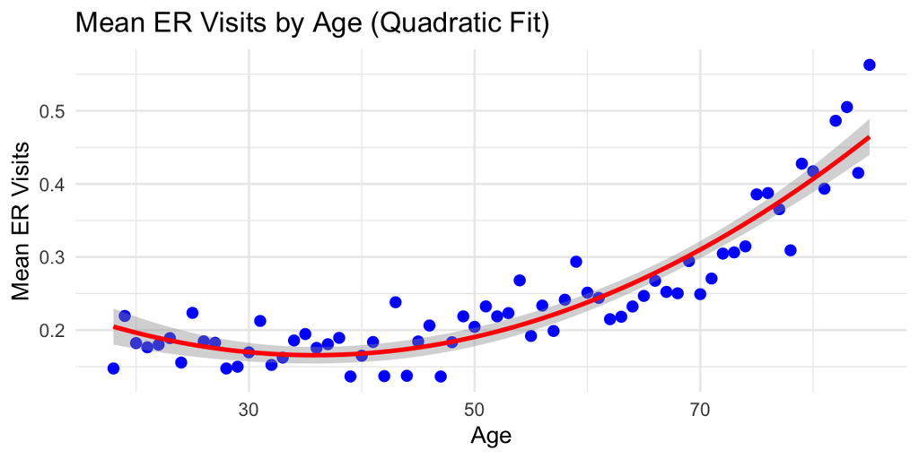

```r
# aggregate the data to calculate mean er visits
agg <- aggregate(data = meps_combined, er_visits ~ age, FUN = "mean")

# square age
agg <- agg %>%
  mutate(age_squared = age^2)

# create the scatterplot
ggplot(agg, aes(x = age, y = er_visits)) +
  geom_point(color = "blue", size = 2) +
  geom_smooth(
    method = "lm",
    formula = y ~ x + I(x^2),
    color = "red",
    se = TRUE
  ) +
  labs(
    title = "Mean ER Visits by Age (Quadratic Fit)",
    x = "Age",
    y = "Mean ER Visits"
  ) +
  theme_minimal()
```

In this case I plotted a scatterplot of age on the x axis and the mean visits to the ER on the Y axis. Through this plot I found a non-linear, quadratic relationship between age and mean ER visits. This suggests that ER utilization may have remianed relatively low and somewhat stable for most of people’s adulthood, however visitation sharply increases once people get even older. Essentially, the probability of an ER visit accelerates significantly as people age rather than remaining at a constant rate. This suggests that older individuals around the range of 70 have a higher demand for emergency care likely due to increased illnesses, chronic conditions, and more frequent hospitalizations that may come from events such as heart attacks. This could suggest the need for increased preventative care systems and such things to reduce the need of ER dependence as people grow older.

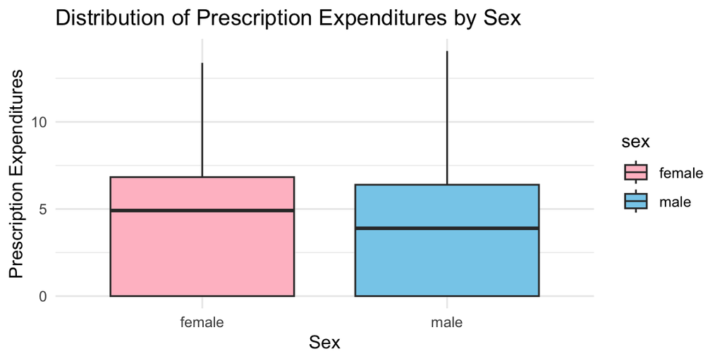

```r
#  box plot
ggplot(meps_combined, aes(x = sex, y = log(prescription_expenditures + 1), fill = sex)) +
  geom_boxplot() +
  labs(
    title = "Distribution of Prescription Expenditures by Sex",
    x = "Sex",
    y = "Prescription Expenditures"
  ) +
  scale_fill_manual(values = c("male" = "skyblue", "female" = "pink")) +
  theme_minimal()
```

Utilizing the combined dataset I used the log of prescription expenditures and sex binary to create a box plot to examine the different sexes’ prescription expenditures. In this box plot I find that the box and median line is slightly bigger and larger for females compared to males. This implies that women on average spend more on prescriptions than men. This could be due to a variety of factors such as women utilizing more healthcare in general due to being more concerned about their health relative to men. In addition, women could potentially have greater prescription drug expenditures in general due to issues exclusive to women and not men, such as reproductive healthcare needs. In addition the bigger box means a hgiher IQR for the females, suggesting more variations in spending, which again could be due to females needing more specialized treatments in comparison to men. Overall these plots reflect gender differences in treatment patterns in men and women, but it could also suggest other factors that are harder to confirm such as differences in access to healthcare, or insurance coverage which I did not include. It could also reflect that certain pricing mechancisms for prescriptions impact men and women in different ways.